# Portfolio Theory with Matrix Algebra

Updated: May 13, 2021

Copyright © Eric Zivot 2015, 2016, 2021

In this chapter, we extend the mean-variance portfolio theory introduced in chapter @ref(Introduction-to-Portfolio-Theory) to handle more than two risky assets. This extension allows the theory to be applied to the analysis of real world portfolios that consist of many risky assets as well as a risk-free asset. When working with large portfolios, the algebra of representing portfolio expected returns and variances becomes extremely cumbersome. As shown in chapter @ref(Matrix-Algebra-Review), the use of matrix algebra can greatly simplify many of these computations. Matrix algebra formulations are also very useful when it comes to do actual computations on the computer. The matrix algebra formulas are easy to translate into matrix programming languages like R. Popular spreadsheet programs like Microsoft Excel, which are the workhorse programs of many financial houses, can also handle basic matrix calculations. All of this makes it worthwhile to become familiar with matrix techniques for portfolio calculations.

This chapter is laid out as follows. Section 1 describes portfolios with $N$ risky assets using matrix algebra. The concept of portfolio risk diversification is elaborated using calculations for large portfolios. Sections 2 through 5 cover the matrix algebra calculations required for determining mean-variance efficient portfolios. Explicit formulas are given for the global minimum variance portfolio, a minimum variance portfolio that achieves a specified target expected return, and the tangency portfolio. A simple algorithm to easily trace out the risky asset only efficient frontier is also presented. Section 6 discusses some practical problems associated with very large portfolios, and section 7 introduces the **IntroCompFinR** functions for portfolio analysis. Section 9 gives a real-world application of the theory to asset allocation among Vanguard mutual funds.

The examples in this chapter use the **corrplot**, **IntroCompFinR** and **PerformanceAnalytics** packages. Make sure these packages are installed and loaded in R before replicating the chapter examples.

```r
suppressPackageStartupMessages(library(corrplot))
suppressPackageStartupMessages(library(IntroCompFinR))
suppressPackageStartupMessages(library(PerformanceAnalytics))
options(digits=3)
```

## Portfolio Analysis Functions in R

The package **IntroCompFinR** contains a few R functions for computing Markowitz mean-variance efficient portfolios allowing for short sales using matrix algebra computations. These functions allow for the easy computation of the global minimum variance portfolio, an efficient portfolio with a given target expected return, the tangency portfolio, and the efficient frontier. These functions are summarized in Table @ref(tab:TablePorfolioFunctions).

(#tab:TablePorfolioFunctions) **IntroCompFinR** functions for computing mean-variance efficient portfolios

| **Function** | **Description** |
| --- | --- |
| `getPortfolio` | create portfolio object |
| `globalMin.portfolio` | compute global minimum variance portfolio |
| `efficient.portfolio` | compute minimum variance portfolio subject to target return |
| `tangency.portfolio` | compute tangency portfolio |
| `efficient.frontier` | compute efficient frontier of risky assets |

The following examples illustrate the use of the functions in Table @ref(tab:TablePorfolioFunctions) using the example data in Table @ref(tab:Table-ThreeAssetExample):

```r
asset.names <- c("MSFT", "NORD", "SBUX")
mu.vec = c(0.0427, 0.0015, 0.0285)
sigma.mat = matrix(c(0.0100, 0.0018, 0.0011,
           0.0018, 0.0109, 0.0026,
           0.0011, 0.0026, 0.0199),
         nrow=3, ncol=3)
r.f=0.005
mu.vec
```

```
## [1] 0.0427 0.0015 0.0285
```

```r
sigma.mat
```

```
##        [,1]   [,2]   [,3]
## [1,] 0.0100 0.0018 0.0011
## [2,] 0.0018 0.0109 0.0026
## [3,] 0.0011 0.0026 0.0199
```

```r
r.f
```

```
## [1] 0.005
```

To specify a `portfolio` object, you need an expected return vector and covariance matrix for the assets under consideration as well as a vector of portfolio weights. To create an equally weighted portfolio use:

```r
library(IntroCompFinR)
ew = rep(1,3)/3
equalWeight.portfolio = getPortfolio(er=mu.vec,cov.mat=sigma.mat,weights=ew)
class(equalWeight.portfolio)
```

```
## [1] "portfolio"
```

Portfolio objects have the following components:

```r
names(equalWeight.portfolio)
```

```
## [1] "call"    "er"      "sd"      "weights"
```

There are `print()`, `summary()` and `plot()` methods for portfolio objects. The `print()` method gives:

```r
equalWeight.portfolio
```

```
## Call:
## getPortfolio(er = mu.vec, cov.mat = sigma.mat, weights = ew)
##
## Portfolio expected return:     0.0242
## Portfolio standard deviation:  0.0759
## Portfolio weights:
## [1] 0.333 0.333 0.333
```

The `plot()` method shows a bar chart of the portfolio weights:

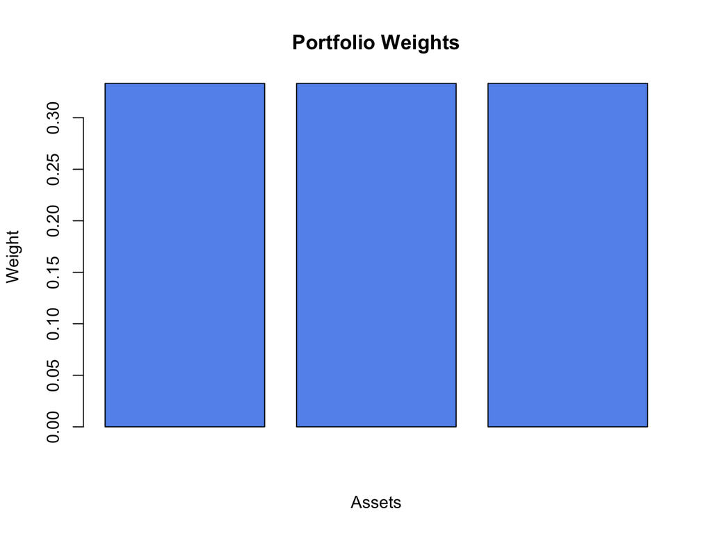

Plot method for objects of class “portfolio”

```r
plot(equalWeight.portfolio, col="cornflowerblue")
```

The resulting plot is shown in Figure @ref(fig:PortMatrixPlotMethod). The global minimum variance portfolio (allowing for short sales) $\mathbf{m}$ solves the optimization problem @ref(eq:PortMatrixGlobalMinObjective) and is computed using @ref(eq:PortMatrixGlobalMinSolution). To compute this portfolio use the function `globalMin.portfolio()`:

```r
gmin.port = globalMin.portfolio(mu.vec, sigma.mat)
class(gmin.port)
```

```
## [1] "portfolio"
```

```r
gmin.port
```

```
## Call:
## globalMin.portfolio(er = mu.vec, cov.mat = sigma.mat)
##
## Portfolio expected return:     0.0249
## Portfolio standard deviation:  0.0727
## Portfolio weights:
## [1] 0.441 0.366 0.193
```

A mean-variance efficient portfolio $\mathbf{x}$ that achieves the target expected return $\mu_{0}$ solves the optimization problem @ref(eq:PortMatrixEfficientPortfolio2) and is computed using @ref(eq:PortMatrixEfficientPortfolioSolution). To compute this portfolio for the target expected return $\mu_{0}=E[R_{\textrm{msft}}]=0.0427$ use the `efficient.portfolio()` function:

```r
target.return = mu.vec[1]
e.port.msft = efficient.portfolio(mu.vec, sigma.mat, target.return)
class(e.port.msft)
```

```
## [1] "portfolio"
```

```r
e.port.msft
```

```
## Call:
## efficient.portfolio(er = mu.vec, cov.mat = sigma.mat, target.return = target.return)
##
## Portfolio expected return:     0.0427
## Portfolio standard deviation:  0.0917
## Portfolio weights:
## [1]  0.8275 -0.0907  0.2633
```

The tangency portfolio $\mathbf{t}$ is the portfolio of risky assets with the highest Sharpe’s slope and has solutions given by @ref(eq:PortMatrixTangencySolution). To compute this portfolio with $r_{f}=0.005$ use the `tangency.portfolio()` function:

```r
tan.port = tangency.portfolio(mu.vec, sigma.mat, r.f)
class(tan.port)
```

```
## [1] "portfolio"
```

```r
tan.port
```

```
## Call:
## tangency.portfolio(er = mu.vec, cov.mat = sigma.mat, risk.free = r.f)
##
## Portfolio expected return:     0.0519
## Portfolio standard deviation:  0.112
## Portfolio weights:
## [1]  1.027 -0.326  0.299
```

```r
ef = efficient.frontier(mu.vec, sigma.mat, alpha.min=-0.5,
                        alpha.max=2, nport=20)
attributes(ef)
```

```
## $names
## [1] "call"    "er"      "sd"      "weights"
##
## $class
## [1] "Markowitz"
```

```r
ef
```

```
## Call:
## efficient.frontier(er = mu.vec, cov.mat = sigma.mat, nport = 20,
##     alpha.min = -0.5, alpha.max = 2)
##
## Frontier portfolios' expected returns and standard deviations
##    port 1 port 2 port 3 port 4 port 5 port 6 port 7 port 8 port 9 port 10
## ER 0.0516 0.0493 0.0469 0.0446 0.0422 0.0399 0.0375 0.0352 0.0329  0.0305
## SD 0.1109 0.1055 0.1003 0.0954 0.0908 0.0866 0.0828 0.0795 0.0769  0.0748
##    port 11 port 12 port 13 port 14 port 15 port 16 port 17 port 18 port 19
## ER  0.0282  0.0258  0.0235  0.0211  0.0188  0.0165  0.0141  0.0118  0.0094
## SD  0.0734  0.0727  0.0728  0.0736  0.0751  0.0773  0.0802  0.0835  0.0874
##    port 20
## ER  0.0071
## SD  0.0917
```

Use the `summary()` method to show the weights of these portfolios. Use the `plot()` method to create a simple plot the efficient frontier:

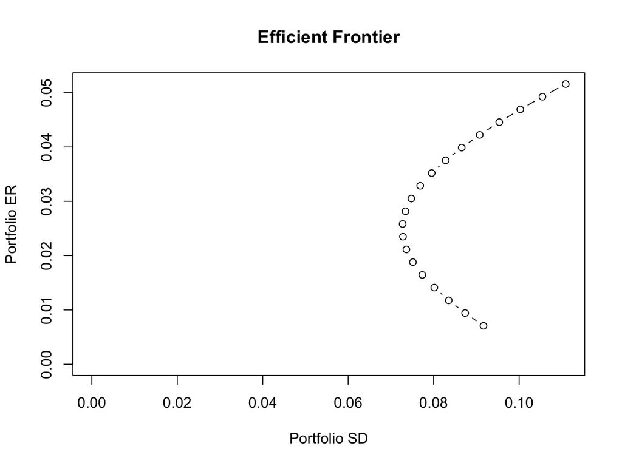

Plot method for objects of class “Markowitz”

```r
plot(ef)
```

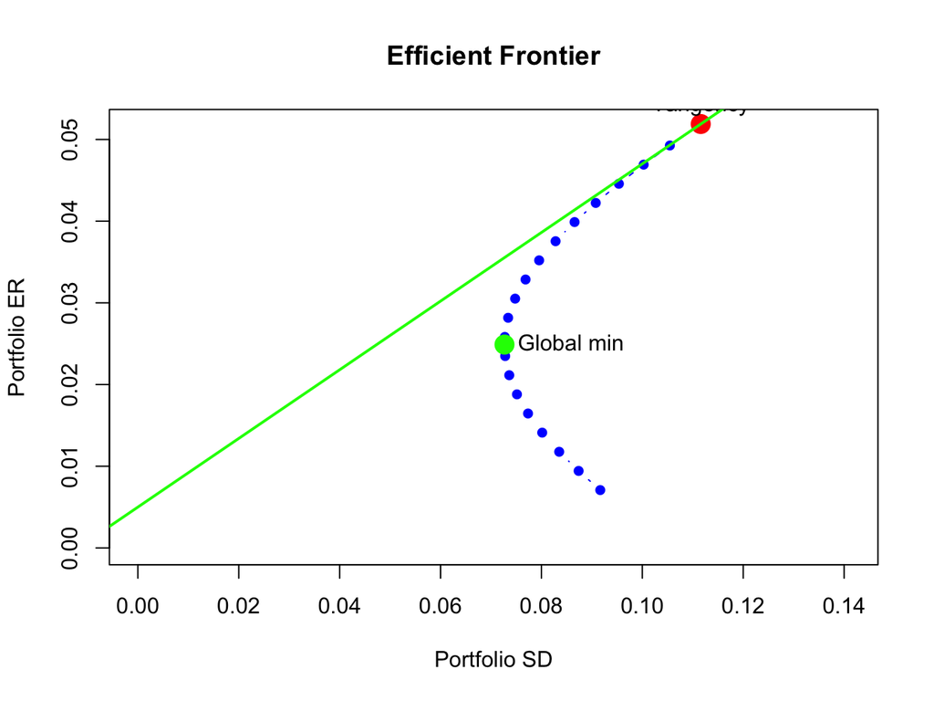

Efficient frontier plot.

```r
plot(ef, plot.assets=T, col="blue", pch=16)
points(gmin.port$sd, gmin.port$er, col="green", pch=16, cex=2)
text(gmin.port$sd, gmin.port$er, labels = "Global min", pos = 4)
points(tan.port$sd, tan.port$er, col="red", pch=16, cex=2)
text(tan.port$sd, tan.port$er, labels = "Tangency", pos = 3)
sr.tan = (tan.port$er - r.f)/tan.port$sd
abline(a=r.f, b=sr.tan, col="green", lwd=2)
```

The resulting plot is shown in Figure @ref(fig:PortMatrixEfficientFrontierPlot).